# How Indicative Can Internet Usage Be For Country Growth?

# Introduction

The World Wide Web was made available to the public in 1993, principly developed by a computer scientest named "Tim Berners Lee". Thanks to him, with the introduction of the W.W.W. and it's abilty to use the internet, this conglomerate network of computers (global now), it practically changed the lives of everyone on earth. Some say it is even the greatest human invention in existence and it is not hard to see why. Imagine not having it, ponder on the implications that entails, the evolvement of man unfold exceptionally different. However, if there may exist such a great intensity between survival and virutal connectednes, then what could that infer about the development of a country and their use of internet? For countries to prosper, is it inately required for them to have access to the web? How about for their educational system, would their be a reliance on the internet to achieve a larger educated country? How significant is the internet on a countries workforce? Finally, what could this denote for countries that are poor in economy, would they need a larger access of internet to rise from their global rankings? All questions that are of priority in our investigation today.

Since my questions have laid the focus of this examination, then I will need data that relates to most of those questions, then we may be able to later arrive at conclusions over the questions that I did not gather data on

# Data Collection

```python
!pip install folium
!pip install geopy
from geopy.geocoders import Nominatim
from sklearn import linear_model
import matplotlib.pyplot as plt
import pandas as pd
import numpy as np
import folium


internet_df = pd.read_csv("https://raw.githubusercontent.com/Nick-Arrazola/320-Workspace/main/share-of-individuals-using-the-internet%20(1).csv")
#country_mean_yearly_schooling_df = pd.read_csv("https://raw.githubusercontent.com/Nick-Arrazola/320-Workspace/main/mean-years-of-schooling-1.csv")
country_yearly_tritary_completion_df = pd.read_csv("https://raw.githubusercontent.com/Nick-Arrazola/320-Workspace/main/share-of-the-population-with-completed-tertiary-education.csv")
total_yearly_employment_df = pd.read_csv("https://raw.githubusercontent.com/Nick-Arrazola/Nick-Arrazola.github.io/main/Total%20Employement%20Per%20Country.csv")
yearly_gni_country_df = pd.read_csv("https://raw.githubusercontent.com/Nick-Arrazola/Nick-Arrazola.github.io/main/GNI%20per%20country%20time%20series.csv", encoding='cp1252')
```

# what about getting rid of missing data?

# Data Tidying

You can see from the image below, that we have some missing data in the form of '..' or 'NaN'. We don't want to use these rows at all since they will have no purpose. The rows with 'NaN' are rows in the dataset that were just empty meaning they don't belong to a country, so we don't we need it, it would just look better if we took it out instead of having wasted space in our dataframe. Likewise, the rows with '..' are countries that have no data related to it at all, so it would seem resonable to just drop those rows/ countries as they have no data related to them at all. I could replace the '..' with zeros, but then if I were to ever calculate the average value in respect to this data, then the zeros would heavily influence the mean as they would be heavy outliers since most of the data is in the thousands and up.

The same idea would apply for the other datasets.

Some of the datasets may be formatted differently than the others:

```
- ex: country1 year1 year2 year3 year4 ...

- ex: country1 year1
      country1 year2
      country1 year3
      country1 year4
```

However, I would like to format all of the datasets to be like the 2nd example, so to do that, I will have to use a function called '.melt(...)', that accomplishes just this. The reason of formating the datasets like that is because if any year (let's say year1 following the example) was empty/ missing data, then I could just drop the row with year1 by itself, while maintaining the other rows. If I had it in the previous format (as shown in example 1), then if I wanted to drop the row with the empty year1, since they are all on the same row, all of the years would get dropped as a result.

Also, I would like to center my focus from years 1990 - 2016 as those are the years my datasets have most in common, so I will drop any columns (or rows) where the years are < 1990 or > 2016. Likewise, to make the tables look cleaner, I will drop any columns (or rows) that seem unnecessary.

```python
print(total_yearly_employment_df)
```

```
                 Country Name Country Code  \
0                 Afghanistan          AFG
1                     Albania          ALB
2                     Algeria          DZA
3              American Samoa          ASM
4                     Andorra          AND
..                        ...          ...
242                       NaN          NaN
243                       NaN          NaN
244                       NaN          NaN
245  Data from database: Jobs          NaN
246  Last Updated: 02/17/2021          NaN

                            Series Name  Series Code 1990 [YR1990]  \
0    Total employment, total (ages 15+)  SL.EMP.TOTL            ..
```

[output cut: 64 more lines]

```python
#-----------------------------------------
#i don't want these columns in the dataframe
columns_drop = ['Series Name', 'Series Code']


for index, row in total_yearly_employment_df.iterrows():
    for i in range(0, len(row)):
        if (row[i] == '..'):
            row[i] = np.nan

#going to re-name columns
total_yearly_employment_df = total_yearly_employment_df.rename(columns = {'1991 [YR1991]' : '1991', '1992 [YR1992]' : '1992', '1993 [YR1993]' : '1993',
                                                                          '1994 [YR1994]' : '1994', '1995 [YR1995]' : '1995', '1996 [YR1996]' : '1996',
                                                                          '1997 [YR1997]' : '1997', '1998 [YR1998]' : '1998', '1999 [YR1999]' : '1999',
                                                                          '2000 [YR2000]' : '2000', '2001 [YR2001]' : '2001', '2002 [YR2002]' : '2002',
                                                                          '2003 [YR2003]' : '2003', '2004 [YR2004]' : '2004', '2005 [YR2005]' : '2005',
                                                                          '2006 [YR2006]' : '2006', '2007 [YR2007]' : '2007', '2008 [YR2008]' : '2008',
                                                                          '2009 [YR2009]' : '2009', '2010 [YR2010]' : '2010', '2011 [YR2011]' : '2011',
                                                                          '2012 [YR2012]' : '2012', '2013 [YR2013]' : '2013', '2014 [YR2014]' : '2014',
                                                                          '2015 [YR2015]' : '2015', '2016 [YR2016]' : '2016'
                                                                        })

sub_yearly_employment_df = total_yearly_employment_df.drop(columns_drop, axis = 'columns', inplace = False)
employment_melt_df = pd.melt(sub_yearly_employment_df, id_vars = ['Country Name', 'Country Code']).sort_values(by = ['Country Name', 'variable'], ascending = True)

employment_melt_df = employment_melt_df.dropna()
employment_melt_df = employment_melt_df.rename(columns = {'variable' : 'Year', 'value' : 'Employment'})

#changes the column elements from being of datatype string to being of datatype float
employment_melt_df['Employment'] = employment_melt_df['Employment'].astype(float)
employment_melt_df
#-----------------------------------------
```

|  | Country Name | Country Code | Year | Employment |
| --- | --- | --- | --- | --- |
| 247 | Afghanistan | AFG | 1991 | 3062014.0 |
| 494 | Afghanistan | AFG | 1992 | 3358951.0 |
| 741 | Afghanistan | AFG | 1993 | 3564855.0 |
| 988 | Afghanistan | AFG | 1994 | 3828863.0 |
| 1235 | Afghanistan | AFG | 1995 | 4228323.0 |
| ... | ... | ... | ... | ... |
| 5675 | Zimbabwe | ZWE | 2012 | 6749094.0 |
| 5922 | Zimbabwe | ZWE | 2013 | 6922911.0 |
| 6169 | Zimbabwe | ZWE | 2014 | 7102680.0 |
| 6416 | Zimbabwe | ZWE | 2015 | 7287739.0 |
| 6663 | Zimbabwe | ZWE | 2016 | 7478802.0 |

5504 rows × 4 columns

```python
#-----------------------------------------
#i don't want these columns from the dataframe
columns_to_drop = ['2017', '2018', '2019', '2020']

#done to not overwrite the dataframe in memory (if 'inplace = TRUE')
#because I might need to use the columns that I got rid of now, later
sub_yearly_gni_df = yearly_gni_country_df.drop(columns_to_drop, axis = 'columns', inplace = False)

sub_yearly_gni_df.dropna()
gni_melt_df = pd.melt(sub_yearly_gni_df, id_vars = ['Country Name', 'Country Code']).sort_values(by = ['Country Name', 'variable'], ascending = True)

gni_melt_df = gni_melt_df.dropna()
gni_melt_df = gni_melt_df.rename(columns = {'variable' : 'Year', 'value' : 'GNI'})
gni_melt_df
#-----------------------------------------
```

|  | Country Name | Country Code | Year | GNI |
| --- | --- | --- | --- | --- |
| 5017 | Afghanistan | AFG | 2009 | 1520.0 |
| 5281 | Afghanistan | AFG | 2010 | 1710.0 |
| 5545 | Afghanistan | AFG | 2011 | 1700.0 |
| 5809 | Afghanistan | AFG | 2012 | 1920.0 |
| 6073 | Afghanistan | AFG | 2013 | 2020.0 |
| ... | ... | ... | ... | ... |
| 6071 | Zimbabwe | ZWE | 2012 | 2070.0 |
| 6335 | Zimbabwe | ZWE | 2013 | 2310.0 |
| 6599 | Zimbabwe | ZWE | 2014 | 2360.0 |
| 6863 | Zimbabwe | ZWE | 2015 | 2410.0 |
| 7127 | Zimbabwe | ZWE | 2016 | 2560.0 |

6084 rows × 4 columns

```python
internet_df = internet_df.rename(columns = {'Entity' : 'Country Name', 'Code' : 'Country Code',
                                            'Individuals using the Internet (% of population)' : 'Internet Usage (% of pop)'
                                           })
internet_df = internet_df.loc[internet_df['Year'] < 2017]
internet_df = internet_df.dropna().sort_values(by = ['Country Name', 'Year'], ascending = True)
internet_df
```

|  | Country Name | Country Code | Year | Internet Usage (% of pop) |
| --- | --- | --- | --- | --- |
| 0 | Afghanistan | AFG | 1990 | 0.000000 |
| 1 | Afghanistan | AFG | 2001 | 0.004723 |
| 2 | Afghanistan | AFG | 2002 | 0.004561 |
| 3 | Afghanistan | AFG | 2003 | 0.087891 |
| 4 | Afghanistan | AFG | 2004 | 0.105809 |
| ... | ... | ... | ... | ... |
| 5924 | Zimbabwe | ZWE | 2012 | 12.000000 |
| 5925 | Zimbabwe | ZWE | 2013 | 15.500000 |
| 5926 | Zimbabwe | ZWE | 2014 | 16.364740 |
| 5927 | Zimbabwe | ZWE | 2015 | 22.742818 |
| 5928 | Zimbabwe | ZWE | 2016 | 23.119989 |

4730 rows × 4 columns

```python
#the original df has rows with years from 1970, but I only want the rows from years 1990 and up
country_yearly_tritary_completion_df = country_yearly_tritary_completion_df.loc[country_yearly_tritary_completion_df['Year'] >= 1990]
country_yearly_tritary_completion_df = country_yearly_tritary_completion_df.rename(columns = {'Entity' : 'Country Name',
                                                                                              'Code' : 'Country Code',
                                                                                              'Barro-Lee: Percentage of population age 15+ with tertiary schooling. Completed Tertiary' : 'Completed Tertiary (% of pop)'
                                                                                             })

country_yearly_tritary_completion_df
```

|  | Country Name | Country Code | Year | Completed Tertiary (% of pop) |
| --- | --- | --- | --- | --- |
| 4 | Afghanistan | AFG | 1990 | 2.91 |
| 5 | Afghanistan | AFG | 1995 | 3.28 |
| 6 | Afghanistan | AFG | 2000 | 3.50 |
| 7 | Afghanistan | AFG | 2005 | 3.61 |
| 8 | Afghanistan | AFG | 2010 | 3.65 |
| ... | ... | ... | ... | ... |
| 1291 | Zimbabwe | ZWE | 1990 | 1.83 |
| 1292 | Zimbabwe | ZWE | 1995 | 1.32 |
| 1293 | Zimbabwe | ZWE | 2000 | 0.53 |
| 1294 | Zimbabwe | ZWE | 2005 | 0.44 |
| 1295 | Zimbabwe | ZWE | 2010 | 0.38 |

720 rows × 4 columns

I was planning on merging the most of the tables into one, larger table containing columns: Country Name, Country Code, Year, GNI, Internet Usage, Tertiary, and Employment, but to do so without having any NaN, I would have to perform some sort of intersect where all of the rows with the same Country Name and Year would be included on the same row in the merge table. Since not all of the tables have the same amount of country and year occurences, some of the rows we have in the individual tables may not be included in the merge table. Therefore, to not lose any more data/observations, I will keep the tables individually.

Now, the real data our tables collectively have are:

```
- Country Name: The name of the country
- Country Code: An identifier for the country
- Year: The year our observation took place
- GNI: The Gross National Income of a country in a certain year
- Internet Usage: Penetration percentage on number of internet users in repect country pop.
- Employment: The total employment of a country in a certain year
- Teritary: Percent of people who completed teritary level education in a country that year
    - Teritary level includes colleges, university, etc.
```

# Explanatory Analysis & Data Visualization

#### Cool, so we know have the data, but what does that data suggest when illustarted? Will the internet usage have some relation with the developemental properties of these countries? Well, that is what will like to find out.

First, let us see what the internet usuage per year looks like between these countries

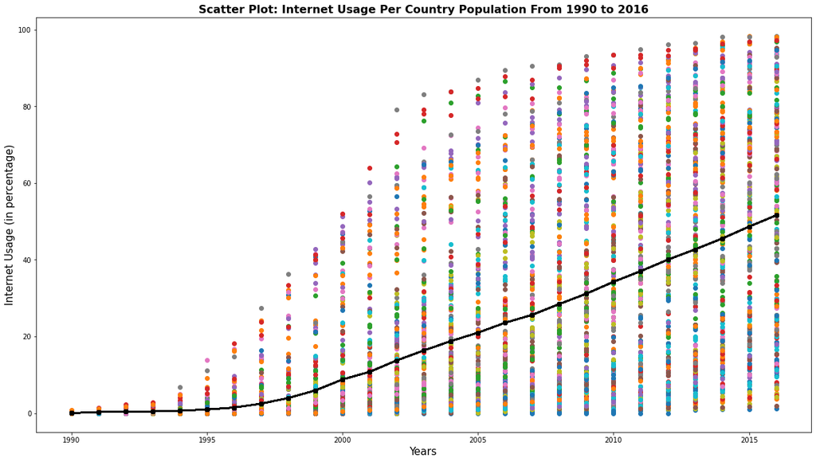

```python
#gets the unique country names in our dataframe
unique_country_names = pd.unique(internet_df['Country Name'])
mean_list = []

plt.figure(figsize = (20,11))

#finding the mean of internet usage per year
mean_usage_df = internet_df[['Year','Internet Usage (% of pop)']].groupby('Year').mean()

for country in unique_country_names:
    #gets the sub-dataframe that has all the rows that includes the current country
    curr_country_stats_df = internet_df.loc[internet_df['Country Name'] == country]

    #plots the internet usage of the current country from 1990 to 2016
    plt.scatter(curr_country_stats_df['Year'], curr_country_stats_df['Internet Usage (% of pop)'])

    plt.plot(mean_usage_df, marker = 'o', markersize = 5, color = 'black',
             markerfacecolor = 'black', linewidth = 2)

plt.title("Scatter Plot: Internet Usage Per Country Population From 1990 to 2016", fontsize = 16, fontweight = "bold")
plt.xlabel("Years", fontsize = 15)
plt.ylabel("Internet Usage (in percentage)", fontsize = 15)
plt.show()
```

Though this is fascinating, we can still see how in relatively recent years, (granted this data is a bit out dated) there still are plentiful quantites of countries that still have low percentages of internet penetration as we can see many below the moving average (black line), how would those countries stand on an economic basis?

Before we do that, I would like to first see where the lowest 50 countries are located worldwide, this could give us more insights towards why they had low internet usage and the general condition of the country. To do I plan on using the data from the most recent year, since that shows use the distribution of data closest to nowaways.

```python
sort_df = internet_df.loc[internet_df['Year'] == 2016].sort_values(by = 'Internet Usage (% of pop)', ascending = True)
sort_50_df = sort_df[0:50]
sort_50_df.head()
```

|  | Country Name | Country Code | Year | Internet Usage (% of pop) |
| --- | --- | --- | --- | --- |
| 1540 | Eritrea | ERI | 2016 | 1.177119 |
| 4944 | Somalia | SOM | 2016 | 1.880000 |
| 2202 | Guinea-Bissau | GNB | 2016 | 3.761414 |
| 880 | Central African Republic | CAF | 2016 | 4.000000 |
| 3963 | Niger | NER | 2016 | 4.322758 |

Great, I now have the list, but I somehow need to find the geographical location of these countries. Thankfully, we can use geopy to convert the name of our desired location into lat and long coordinates so we can map them using folium (a library that allows developers to make maps using python). Let's how it works.

```python
map_osm = folium.Map()

count = 1
for index, row in sort_50_df.iterrows():
    location = geolocator.geocode(row[0])

    folium.Marker(
        location = [location.latitude, location.longitude],
        popup = "Rank: " + str(count) + ", " + row[0] + ", " + str(row[3]) + " penetration",
        icon = folium.Icon(color = 'beige')
        ).add_to(map_osm)

    count += 1
map_osm
```

Make this Notebook Trusted to load map: File -> Trust Notebook

[interactive chart not shown]

This is very informative, as we can see, the majority of countries (as of 2016) that have the lowest usage of internet are distributed throughout Africa. You may be wondering, "how is this map useful?", well this map can give us an indiction of what to execpt of a countries developement stage. The map could be suggesting that these countries marked are also low in economic establishment, however, from this map alone, the relation is not yet definitive. How about we plot something else.

I would now like to proceed in ploting how the countries gross national income has changed throughout the years.

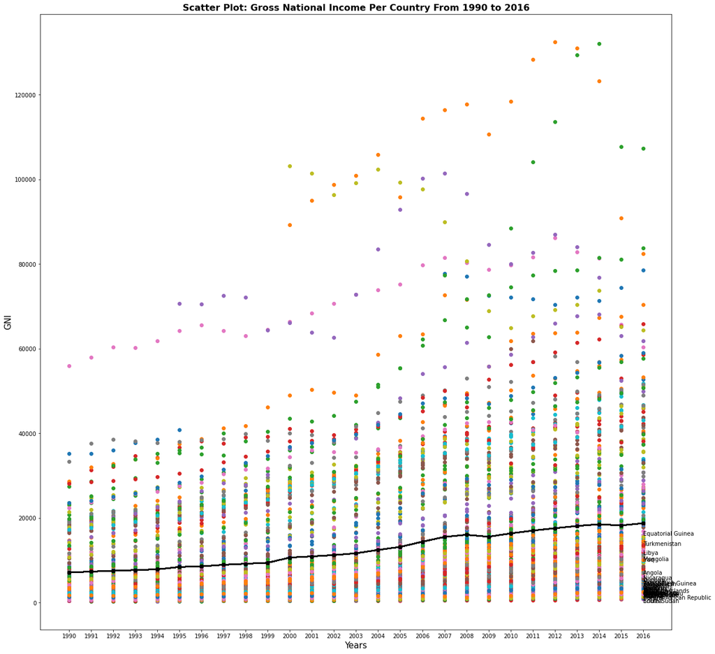

```python
#gets the unique country names in our dataframe
unique_country_names = pd.unique(gni_melt_df['Country Name'])

sort_50_country_lst = list(sort_50_df['Country Name'])
mean_list = []

plt.figure(figsize = (20,20))

#done so that the years would start in a weird order on the x-axis
start_df = gni_melt_df.loc[gni_melt_df['Country Name'] == 'Arab World']
plt.scatter(start_df['Year'], start_df['GNI'])

#finding the mean of internet usage per year
mean_usage_df = gni_melt_df[['Year','GNI']].groupby('Year').mean()

for country in unique_country_names:

    if country == 'Arab World':
        continue

    curr_country_stats_df = gni_melt_df.loc[gni_melt_df['Country Name'] == country]

    #checks to see if the current country is one of the bottom 50 countries in internet usage
    if (country in sort_50_country_lst):
        country_2016_gni = -1
        for index, row in curr_country_stats_df.iterrows():
            if row[2] == '2016':
                country_2016_gni = row[3]
         #going to mark the country in the plot
        plt.annotate(country, ('2016', country_2016_gni))


    #plots the internet usage of the current country from 1990 to 2016
    plt.scatter(curr_country_stats_df['Year'], curr_country_stats_df['GNI'])

    plt.plot(mean_usage_df, marker = 'o', markersize = 5, color = 'black',
             markerfacecolor = 'black', linewidth = 2)

plt.title("Scatter Plot: Gross National Income Per Country From 1990 to 2016", fontsize = 16, fontweight = "bold")
plt.xlabel("Years", fontsize = 15)
plt.ylabel("GNI", fontsize = 15)
plt.show()
```

Ok, there's a bit to unpack here. First off, once again, we can see the the black line to depict the moving average GNI throughout the years. Notice how the line is a lot closer towards the bottom, this most likely is indicative that the majority of the countries have a low GNI number. I say this because there must be a large concentration of GNI scores below 20,000 if the average is depecit being within that interval, it would actually be lower if not for the outliers above the average. Take note that there appears to be a lot of countries high in GNI as the years progress, but if the average is depicted being below 20,000, then that must mean that there are a lot more countries low in GNI than high (huge concentration below 20,000, I should have used a violin plot to show the distribution better).

To actually see if a realtion exists, let us create a plot that visualizes internet usage vs GNI score.

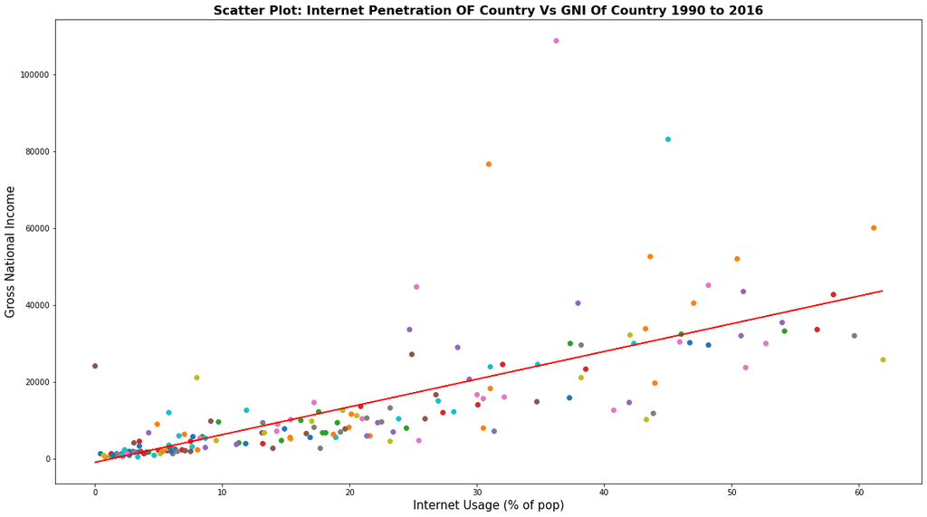

```python
#gets the unique country names in our dataframe
unique_country_names = pd.unique(internet_df['Country Name'])
internet_as_2d_lst = []
gni_list = []

plt.figure(figsize = (20,11))


for country in unique_country_names:
    #gets the sub-dataframe that has all the rows that includes the current country
    country_internet_df = internet_df.loc[internet_df['Country Name'] == country].mean()
    country_gni_df = gni_melt_df.loc[gni_melt_df['Country Name'] == country].mean()

    #plots the internet usage of the current country from 1990 to 2016
    plt.scatter(country_internet_df['Internet Usage (% of pop)'], country_gni_df['GNI'])

    if (not np.isnan(np.min(country_gni_df['GNI']))):
        internet_as_2d_lst.append([country_internet_df['Internet Usage (% of pop)']])
        gni_list.append([country_gni_df['GNI']])



#creates the linear regression model
lm = linear_model.LinearRegression()

#passing in our dataset so that it can be modeled with linear regression
lm.fit(internet_as_2d_lst, gni_list)


estimated_outputs = lm.predict(internet_as_2d_lst)
plt.plot(internet_as_2d_lst, estimated_outputs, color = 'red')

plt.title("Scatter Plot: Internet Penetration OF Country Vs GNI Of Country 1990 to 2016", fontsize = 16, fontweight = "bold")
plt.xlabel("Internet Usage (% of pop)", fontsize = 15)
plt.ylabel("Gross National Income", fontsize = 15)
plt.show()
```

A linear regression here may not be the best choice as their seems to be a final slight curve, hinting that our data is growing a bit larger than linear growth.